# Analisis Kelompok 4

Kelompok 4

2025-10-02

## 1. Packages

```r
library(rio)
library(ggplot2)
library(tsibble)
library(tseries)
library(MASS)
library(readr)
library(TSA)
library(forecast)
library(lubridate)
library(readxl)
library(knitr)
```

## 2. Import Data

```r
url <- "https://raw.githubusercontent.com/rafiadabhi/MPDW/main/Pertemuan%201/Data/SM_Rata2_Mingguan_Indramayu_2014_2023.xlsx"
temp_file <- tempfile(fileext = ".xlsx")
download.file(url, destfile = temp_file, mode = "wb")
df <- read_excel(temp_file)

df_values <- df$sm

start_date <- df[[1]][1]
start_year <- as.integer(format(start_date, "%Y"))
start_week <- as.integer(format(start_date, "%W")) + 1

date_col <- df[[1]]
full_year_vector <- as.integer(format(date_col, "%Y"))

data <- ts(
  df_values,
  start = c(start_year, start_week),
  frequency = 52
)
```

### 2.1 Karakteristik Data

```r
length(data)
```

```
## [1] 522
```

```r
head(data)
```

```
## Time Series:
## Start = c(2014, 1)
## End = c(2014, 6)
## Frequency = 52
## [1] 0.3964956 0.3709459 0.3956903 0.3664664 0.3797440 0.3670196
```

```r
tail(data)
```

```
## Time Series:
## Start = c(2023, 49)
## End = c(2024, 2)
## Frequency = 52
## [1] 0.2909904 0.3257009 0.3519478 0.3508385 0.3377355 0.3788863
```

```r
is.numeric(data)
```

```
## [1] TRUE
```

### 2.2 Data Spliting

```r
train_data <- subset(data,start=1,end=469)
test_data <- subset(data,start=470,end=522)
```

## 3. Eksplorasi Data

```r
summary(data)
```

```
##    Min. 1st Qu.  Median    Mean 3rd Qu.    Max.
##  0.1514  0.2692  0.3420  0.3185  0.3675  0.4273
```

### 3.1 Plot Data Penuh

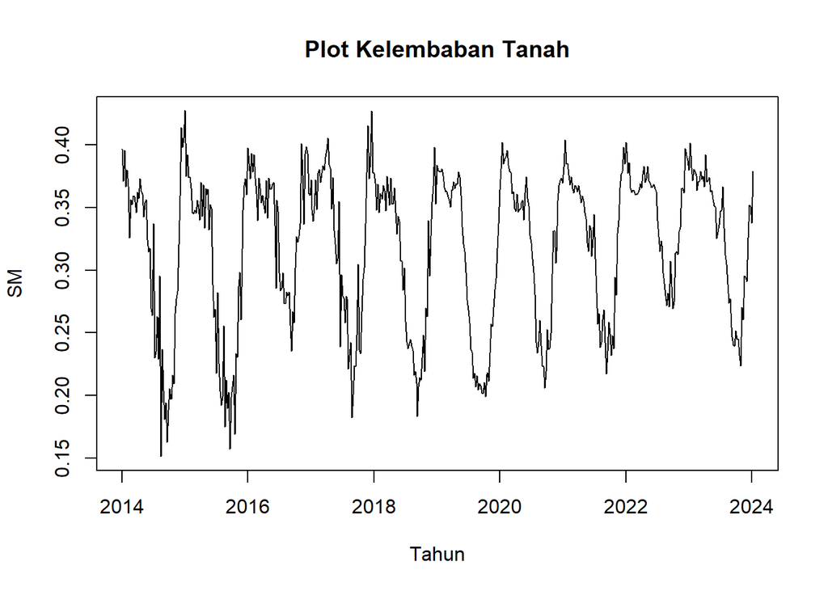

```r
plot.ts(data,
        lty = 1,
        xlab = "Tahun",
        ylab = "SM",
        main = "Plot Kelembaban Tanah")
```

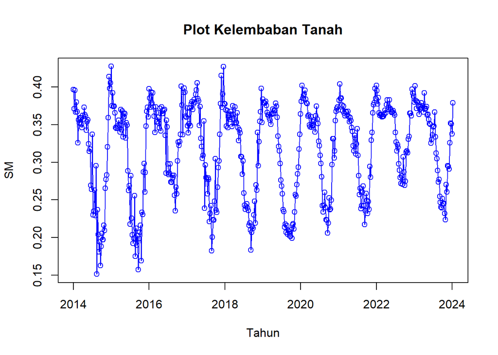

```r
ts.plot(data, type="l", xlab = "Tahun", ylab="SM", col="blue")
title(main = "Plot Kelembaban Tanah", cex.sub = 0.8)
points(data, pch = 1, col = "blue")
```

### 3.2 Plot Data Latih

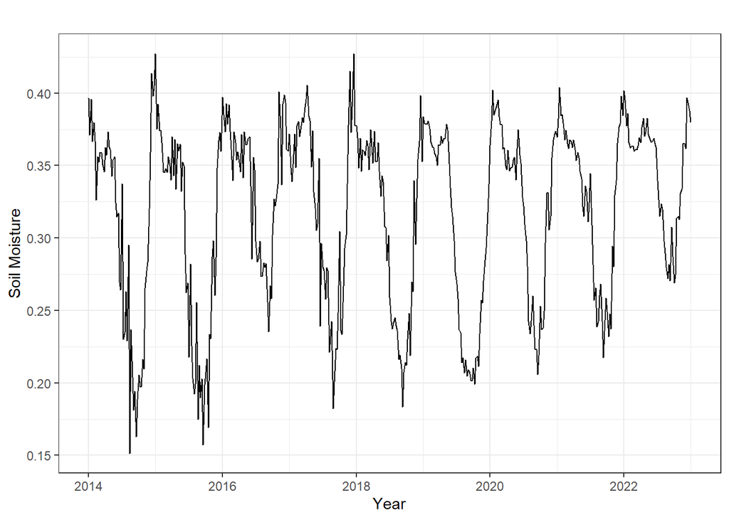

```r
autoplot(train_data) + theme_bw() + xlab("Year") + ylab("Soil Moisture")
```

### 3.3 Plot Data Uji

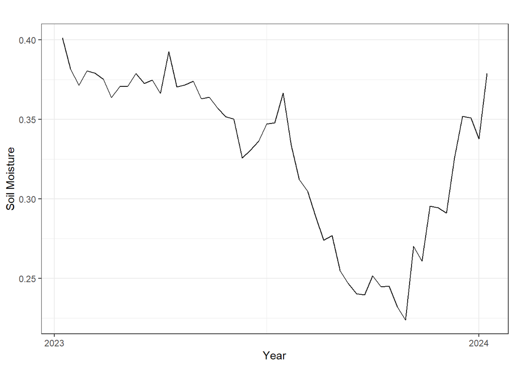

```r
autoplot(test_data) + theme_bw() + xlab("Year") + ylab("Soil Moisture")
```

### 3.3 Plot Seasonal

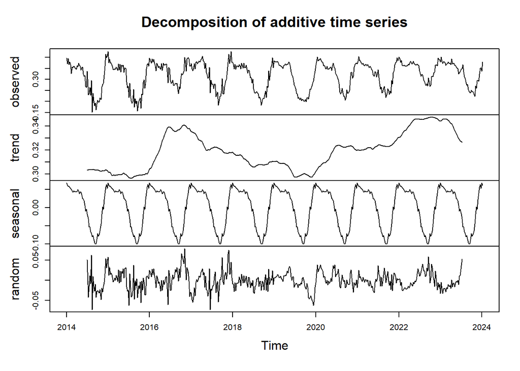

```r
data.tss <- ts(data, frequency = 52, start = c(2014, 1))
dec.data <- decompose(data.tss)
plot(dec.data)
```

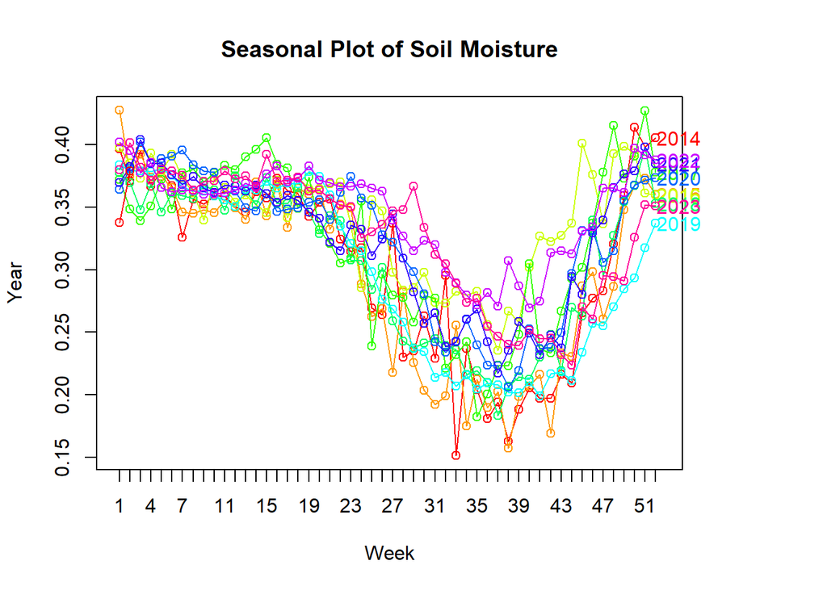

```r
par(mar=c(5, 4, 4, 6) + 0.1, xpd=TRUE)
seasonplot(data,52,main="Seasonal Plot of Soil Moisture", ylab="Year",
           year.labels = TRUE, col=rainbow(10))
```

```r
par(mar=c(5, 4, 4, 2) + 0.1)
```

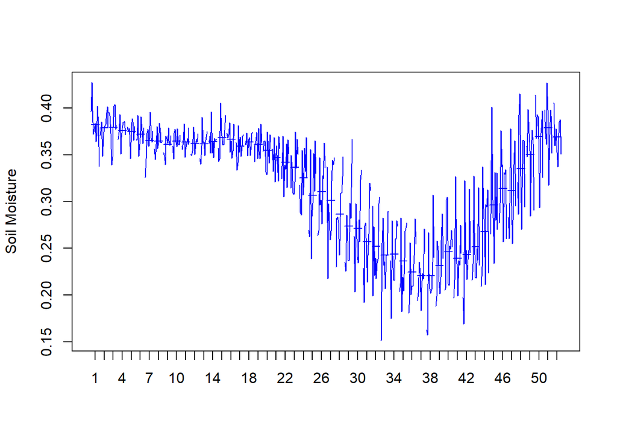

```r
monthplot(data.tss,ylab="Soil Moisture", col="blue")
```

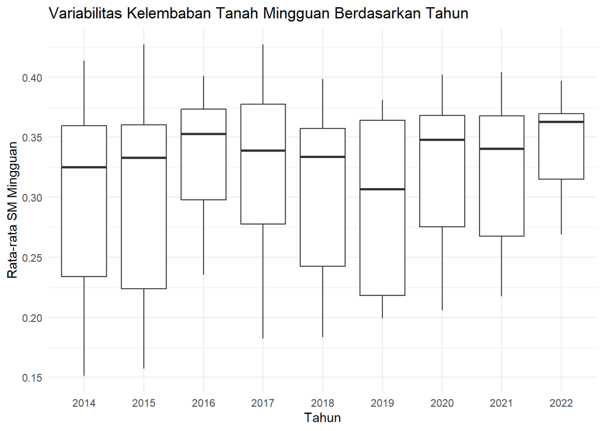

```r
n <- length(data)
n_train <- floor(0.9 * n)
full_year_vector <- as.integer(format(df[[1]], "%Y"))
train_year_vector <- full_year_vector[1:n_train]

frame_fligner_train <- data.frame(
  values = as.numeric(train_data),
  date_year = factor(train_year_vector) # Kelompokkan berdasarkan Tahun (seharusnya 10 level)
)

ggplot(frame_fligner_train, aes(y=values, x=date_year)) +
  geom_boxplot() +
  labs(
    title = "Variabilitas Kelembaban Tanah Mingguan Berdasarkan Tahun",
    x = "Tahun",
    y = "Rata-rata SM Mingguan"
  ) +
  theme_minimal()
```

## 4. Non-seasonal ARIMA

### 4.1 Stasioneritas

```r
# Uji Box-Cox
index <- seq(length(train_data))
bc <- boxcox(
  train_data - min(train_data) + 0.000000000000000000001 ~ index,
  lambda = seq(0.5, 1.5, by = 0.001)
)
```

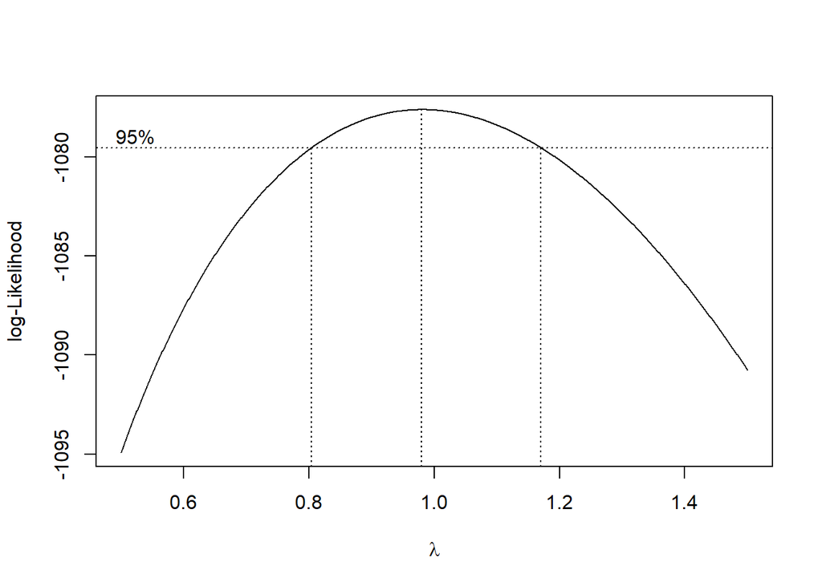

```r
lambda_opt <- bc$x[which.max(bc$y)]
lambda_opt
```

```
## [1] 0.98
```

```r
# Selang kepercayaan 95% untuk lambda
ci_lambda <- bc$x[bc$y > max(bc$y) - 0.5 * qchisq(0.95, 1)]

# Batas bawah dan batas atas
ci_lower <- min(ci_lambda)
ci_upper <- max(ci_lambda)

c(Batas_Bawah = ci_lower, Batas_Atas = ci_upper)
```

```
## Batas_Bawah  Batas_Atas
##       0.804       1.170
```

Hasil uji Box–Cox menunjukkan bahwa nilai λ optimum adalah 0,98 dengan interval kepercayaan 95% sebesar (0,804–1,170). Karena selang tersebut memuat nilai λ = 1, maka dapat disimpulkan bahwa data sudah stasioner dalam ragam

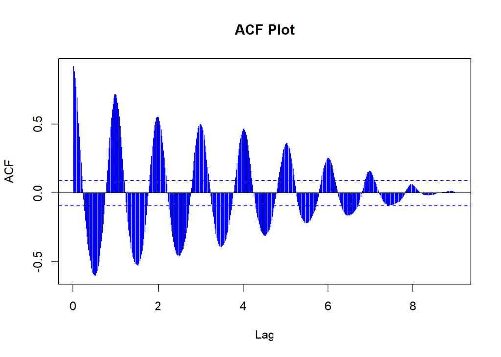

```r
acf(train_data, lag.max = 520, main = "ACF Plot", col = "blue")
```

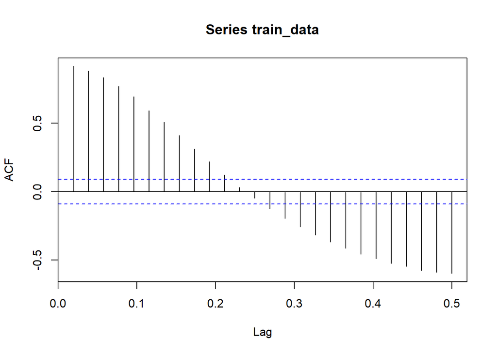

```r
acf(train_data)
```

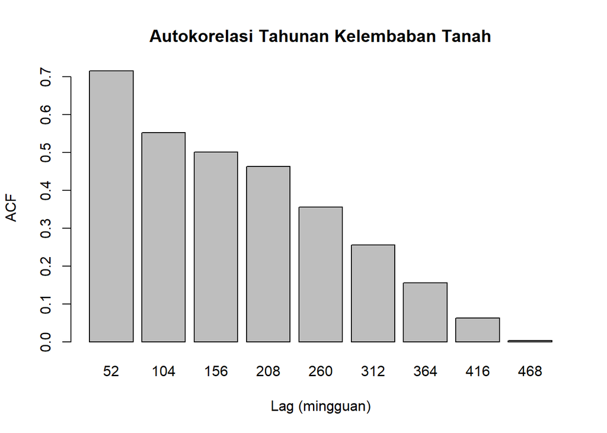

```r
acf0 <- acf(train_data, main = "ACF", lag.max = 520, plot = FALSE)
acf0$lag <- acf0$lag * 52
acf_df <- data.frame(acf = acf0$acf, lag = acf0$lag)

acf_year <- acf_df[acf_df$lag %% 52 == 0, ]   # ← koma di sini penting!

barplot(
  height = acf_year$acf,
  names.arg = acf_year$lag,
  ylab = "ACF",
  xlab = "Lag (mingguan)",
  main = "Autokorelasi Tahunan Kelembaban Tanah"
)
```

```r
tseries::adf.test(train_data)
```

```
##
##  Augmented Dickey-Fuller Test
##
## data:  train_data
## Dickey-Fuller = -6.5973, Lag order = 7, p-value = 0.01
## alternative hypothesis: stationary
```

$H_0$ : Data tidak stasioner dalam rataan $H_1$ : Data stasioner dalam rataan

Berdasarkan uji ADF tersebut, didapat p-value sebesar 0.01 yang lebih kecil dari taraf nyata 5% sehingga tolak $H_0$ dan menandakan bahwa data sudah stasioner dalam rataan.

## 5. Seasonal ARIMA

### 5.1 Identifikasi Model

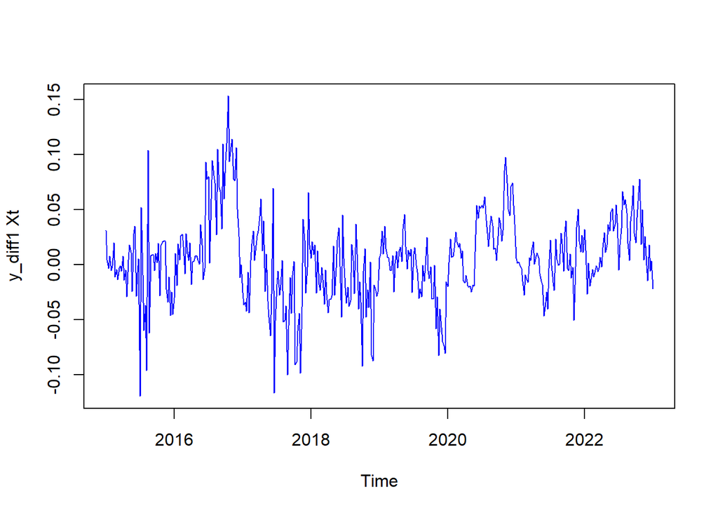

```r
D1 <- diff(train_data, lag = 52)
ts.plot(D1, type="l", ylab="y_diff1 Xt", col="blue")
```

```r
d1D1 <- diff(D1,lag=1)
```

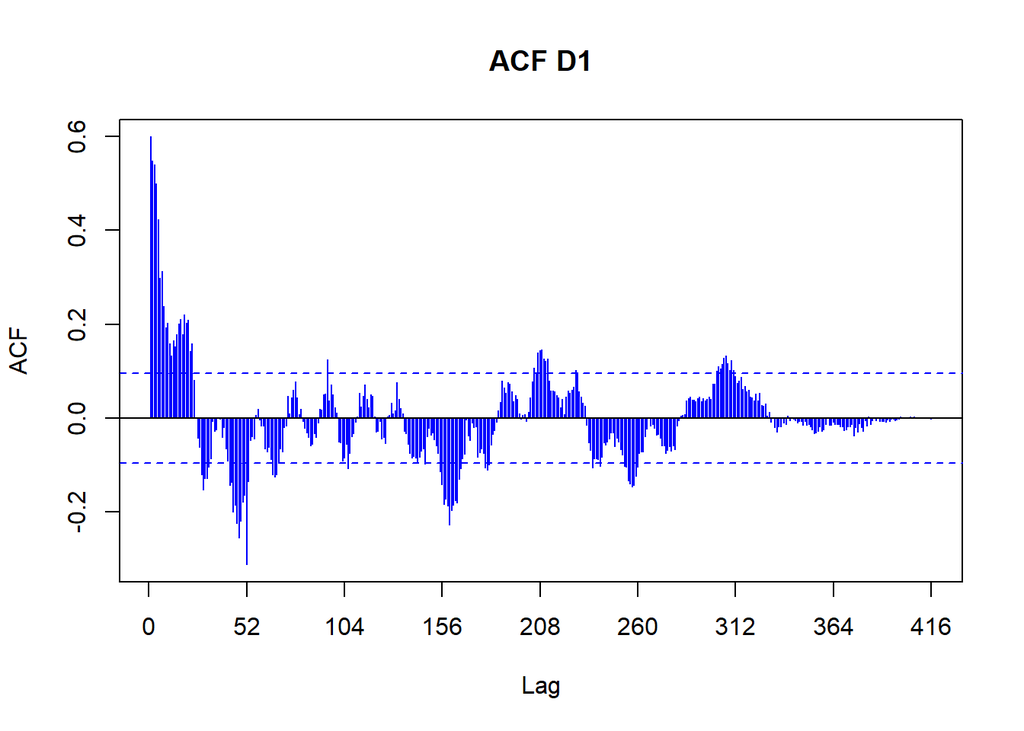

```r
acf3 <- acf(D1, lag.max = 520, xaxt = "n", main = "ACF D1", col = "blue")
lag_pos <- acf3$lag * 52
lag_seasonal <- seq(0, 520, by = 52)
axis(1, at = lag_seasonal / 52, labels = lag_seasonal)
```

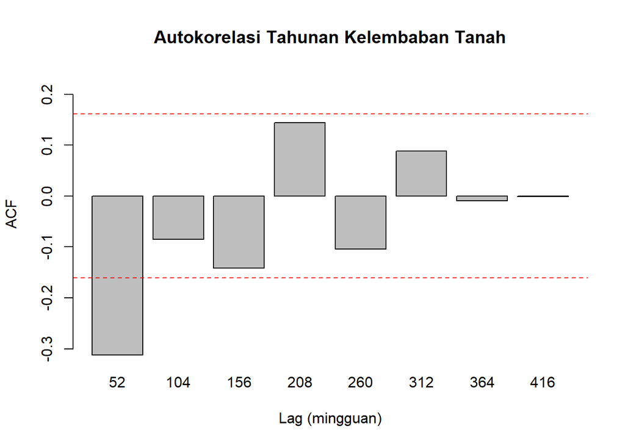

```r
acf0 <- acf(D1, main = "ACF", lag.max = 520, plot = FALSE)
acf0$lag <- acf0$lag * 52
acf_df <- data.frame(acf = acf0$acf, lag = acf0$lag)

acf_year <- acf_df[acf_df$lag %% 52 == 0, ]
alpha <- 0.001
batas <- qnorm(1 - alpha/2) / sqrt(length(D1))


bar_positions <- barplot(
  height = acf_year$acf,
  names.arg = acf_year$lag,
  ylab = "ACF",
  xlab = "Lag (mingguan)",
  main = "Autokorelasi Tahunan Kelembaban Tanah",
  ylim = c(min(acf_year$acf, -batas*1.5), max(acf_year$acf, batas*1.5))
)

abline(h = c(-batas, batas), col = "red", lty = 2)
```

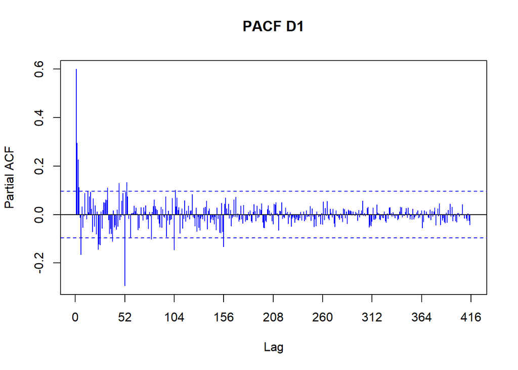

```r
pacf3 <- pacf(D1, lag.max = 520, xaxt = "n", main = "PACF D1", col = "blue")
lag_seasonal <- seq(0, 520, by = 52)
axis(1, at = lag_seasonal / 52, labels = lag_seasonal)
```

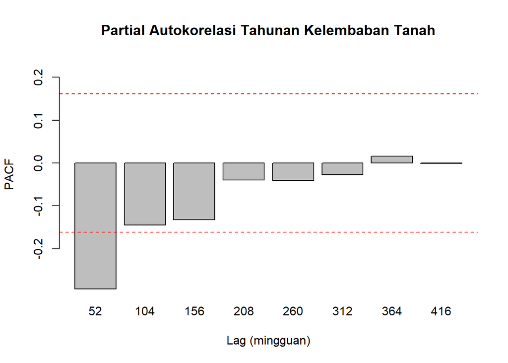

```r
pacf0 <- pacf(D1, lag.max = 520, plot = FALSE)
pacf_df <- data.frame(pacf = pacf0$acf, lag = 1:length(pacf0$acf))
pacf_year <- pacf_df[pacf_df$lag %% 52 == 0, ]

bar_positions <- barplot(
  height = pacf_year$pacf,
  names.arg = pacf_year$lag,
  ylab = "PACF",
  xlab = "Lag (mingguan)",
  main = "Partial Autokorelasi Tahunan Kelembaban Tanah",
  ylim = c(min(pacf_year$pacf, -batas*1.5), max(pacf_year$pacf, batas*1.5))
)
abline(h = c(-batas, batas), col = "red", lty = 2)
```

Berdasarkan plot ACF dan PACF seasonal (s = 52) diperoleh nilai P = 1 dan Q = 1

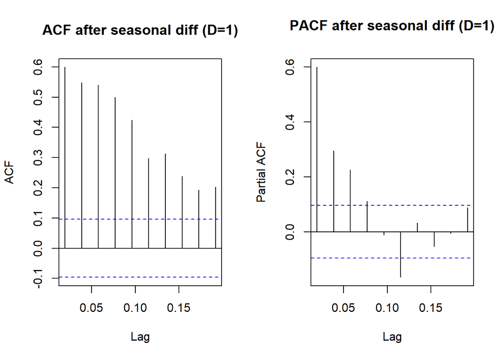

```r
par(mfrow = c(1,2))
acf(D1, lag.max = 10, main = "ACF after seasonal diff (D=1)")
pacf(D1, lag.max = 10, main = "PACF after seasonal diff (D=1)")
```

```r
par(mfrow = c(1,1))
```

Plot ACF menunjukkan tails off dan plot PACF menunjukkan pola cut off pada lag 4. Kriteria tails off pada ACF dan cut off pada PACF merupakan kriteria dari AR dengan ordo p adalah 4 sehingga menghasilkan kandidat model ARIMA(4,0,0).

```r
eacf(D1)
```

```
## AR/MA
##   0 1 2 3 4 5 6 7 8 9 10 11 12 13
## 0 x x x x x x x x x x x  x  x  x
## 1 x o o o x x x o o o o  o  o  o
## 2 x x o o o x x o o o o  o  o  o
## 3 x x o o x o o o o o o  o  o  o
## 4 x x o x x x o o o o o  o  o  o
## 5 o x x x o x o o o o o  o  o  o
## 6 x x x x x x o o o o o  o  o  o
## 7 x x o x x x o o o o o  o  o  o
```

Berdasarkan plot EACF terdapat beberapa kandidat yang memungkinkan diantaranya yaitu: - ARIMA(1,0,1) - ARIMA(1,0,2) - ARIMA(2,0,2) - ARIMA(1,0,7)

Sehingga berdasarkan plot ACF, PACF dan EACF menghasilkan kandidat model: 1. ARIMA(4,0,0) -> tmodel1 2. ARIMA(1,0,1) -> tmodel2 3. ARIMA(1,0,2) -> tmodel3 4. ARIMA(2,0,2) -> tmodel4 5. ARIMA(1,0,7) -> tmodel5

### 5.2 Pendugaan Parameter

#### 5.2.1 ARIMA(4,0,0)(1,1,1)[52]

```r
tmodel1 <- Arima(train_data,order=c(4,0,0),seasonal=c(1,1,1))
summary(tmodel1)
```

```
## Series: train_data
## ARIMA(4,0,0)(1,1,1)[52]
##
## Coefficients:
##          ar1     ar2     ar3     ar4     sar1     sma1
##       0.3590  0.2586  0.1744  0.0471  -0.0166  -0.9772
## s.e.  0.0492  0.0518  0.0516  0.0496   0.0667   0.6059
##
## sigma^2 = 0.000432:  log likelihood = 972.77
## AIC=-1931.54   AICc=-1931.27   BIC=-1903.31
##
## Training set error measures:
##                      ME       RMSE       MAE        MPE     MAPE      MASE
## Training set 0.00121621 0.01945723 0.0135019 0.09652517 4.531128 0.4692354
##                     ACF1
## Training set -0.00448722
```

```r
lmtest::coeftest(tmodel1)
```

```
##
## z test of coefficients:
##
##       Estimate Std. Error z value  Pr(>|z|)
## ar1   0.359006   0.049158  7.3032 2.811e-13 ***
## ar2   0.258592   0.051811  4.9911 6.005e-07 ***
## ar3   0.174361   0.051569  3.3811  0.000722 ***
## ar4   0.047123   0.049565  0.9507  0.341733
## sar1 -0.016565   0.066694 -0.2484  0.803841
## sma1 -0.977233   0.605893 -1.6129  0.106770
## ---
## Signif. codes:  0 '***' 0.001 '**' 0.01 '*' 0.05 '.' 0.1 ' ' 1
```

#### 5.2.2 ARIMA(1,0,1)(1,1,1)[52]

```r
tmodel2 <- Arima(train_data,order=c(1,0,1),seasonal=c(1,1,1))
summary(tmodel2)
```

```
## Series: train_data
## ARIMA(1,0,1)(1,1,1)[52]
##
## Coefficients:
##          ar1      ma1     sar1     sma1
##       0.9223  -0.5054  -0.0144  -0.9952
## s.e.  0.0226   0.0465   0.0586   0.3916
##
## sigma^2 = 0.000429:  log likelihood = 969.74
## AIC=-1929.48   AICc=-1929.34   BIC=-1909.32
##
## Training set error measures:
##                       ME       RMSE        MAE        MPE     MAPE      MASE
## Training set 0.001188851 0.01943592 0.01350121 0.08788888 4.532527 0.4692114
##                     ACF1
## Training set -0.05290729
```

```r
lmtest::coeftest(tmodel2)
```

```
##
## z test of coefficients:
##
##       Estimate Std. Error  z value Pr(>|z|)
## ar1   0.922275   0.022610  40.7898  < 2e-16 ***
## ma1  -0.505443   0.046457 -10.8798  < 2e-16 ***
## sar1 -0.014381   0.058634  -0.2453  0.80625
## sma1 -0.995207   0.391583  -2.5415  0.01104 *
## ---
## Signif. codes:  0 '***' 0.001 '**' 0.01 '*' 0.05 '.' 0.1 ' ' 1
```

#### 5.2.3 ARIMA(1,0,2)(1,1,1)[52]

```r
tmodel3 <- Arima(train_data,order=c(1,0,2),seasonal=c(1,1,1))
summary(tmodel3)
```

```
## Series: train_data
## ARIMA(1,0,2)(1,1,1)[52]
##
## Coefficients:
##          ar1      ma1     ma2     sar1     sma1
##       0.9068  -0.5613  0.1240  -0.0275  -0.9682
## s.e.  0.0257   0.0568  0.0549   0.0702   0.4517
##
## sigma^2 = 0.0004347:  log likelihood = 972.23
## AIC=-1932.47   AICc=-1932.26   BIC=-1908.27
##
## Training set error measures:
##                       ME       RMSE        MAE       MPE     MAPE      MASE
## Training set 0.001259323 0.01954057 0.01355761 0.1109886 4.551223 0.4711714
##                    ACF1
## Training set 0.00777316
```

```r
lmtest::coeftest(tmodel3)
```

```
##
## z test of coefficients:
##
##       Estimate Std. Error z value Pr(>|z|)
## ar1   0.906809   0.025687 35.3017  < 2e-16 ***
## ma1  -0.561274   0.056824 -9.8774  < 2e-16 ***
## ma2   0.124006   0.054874  2.2598  0.02383 *
## sar1 -0.027459   0.070246 -0.3909  0.69587
## sma1 -0.968242   0.451732 -2.1434  0.03208 *
## ---
## Signif. codes:  0 '***' 0.001 '**' 0.01 '*' 0.05 '.' 0.1 ' ' 1
```

#### 5.2.4 ARIMA(2,0,2)(1,1,1)[52]

```r
tmodel4 <- Arima(train_data,order=c(2,0,2),seasonal=c(1,1,1))
summary(tmodel4)
```

```
## Series: train_data
## ARIMA(2,0,2)(1,1,1)[52]
##
## Coefficients:
##         ar1      ar2      ma1     ma2     sar1    sma1
##       1.446  -0.5122  -1.1091  0.4508  -0.0299  -0.927
## s.e.  0.166   0.1537   0.1557  0.0852   0.0726   0.211
##
## sigma^2 = 0.0004453:  log likelihood = 975.04
## AIC=-1936.07   AICc=-1935.8   BIC=-1907.84
##
## Training set error measures:
##                       ME       RMSE        MAE       MPE     MAPE      MASE
## Training set 0.001458006 0.01975384 0.01365961 0.1708509 4.599048 0.4747162
##                     ACF1
## Training set 0.009028433
```

```r
lmtest::coeftest(tmodel4)
```

```
##
## z test of coefficients:
##
##       Estimate Std. Error z value  Pr(>|z|)
## ar1   1.446004   0.166048  8.7083 < 2.2e-16 ***
## ar2  -0.512232   0.153660 -3.3335 0.0008575 ***
## ma1  -1.109119   0.155743 -7.1215 1.068e-12 ***
## ma2   0.450752   0.085207  5.2901 1.223e-07 ***
## sar1 -0.029898   0.072583 -0.4119 0.6804022
## sma1 -0.926996   0.210952 -4.3943 1.111e-05 ***
## ---
## Signif. codes:  0 '***' 0.001 '**' 0.01 '*' 0.05 '.' 0.1 ' ' 1
```

#### 5.2.5 ARIMA(1,0,7)(1,1,1)[52]

```r
tmodel5 <- Arima(train_data,order=c(1,0,7),seasonal=c(1,1,1))
summary(tmodel5)
```

```
## Series: train_data
## ARIMA(1,0,7)(1,1,1)[52]
##
## Coefficients:
```

```
##          ar1      ma1     ma2     ma3     ma4     ma5      ma6     ma7     sar1
##       0.8319  -0.4634  0.0904  0.1105  0.0919  0.0857  -0.1703  0.1354  -0.0149
## s.e.  0.0709   0.0834  0.0594  0.0584  0.0635  0.0598   0.0613  0.0605   0.0028
##          sma1
##       -0.9908
## s.e.      NaN
##
## sigma^2 = 0.0004132:  log likelihood = 981.29
## AIC=-1940.59   AICc=-1939.93   BIC=-1896.22
##
## Training set error measures:
##                       ME       RMSE        MAE       MPE     MAPE      MASE
## Training set 0.001411035 0.01893648 0.01328981 0.1697448 4.488687 0.4618645
##                    ACF1
## Training set -0.0091716
```

```r
lmtest::coeftest(tmodel5)
```

```
##
## z test of coefficients:
##
##        Estimate Std. Error z value  Pr(>|z|)
## ar1   0.8319415  0.0709027 11.7336 < 2.2e-16 ***
## ma1  -0.4634236  0.0834091 -5.5560 2.760e-08 ***
## ma2   0.0904377  0.0594364  1.5216  0.128113
## ma3   0.1104718  0.0584256  1.8908  0.058650 .
## ma4   0.0918740  0.0634828  1.4472  0.147834
## ma5   0.0856939  0.0598267  1.4324  0.152038
## ma6  -0.1703302  0.0612722 -2.7799  0.005438 **
## ma7   0.1354327  0.0605145  2.2380  0.025220 *
## sar1 -0.0148654  0.0028166 -5.2778 1.307e-07 ***
## sma1 -0.9907831        NaN     NaN       NaN
## ---
## Signif. codes:  0 '***' 0.001 '**' 0.01 '*' 0.05 '.' 0.1 ' ' 1
```

#### 5.2.7 Model Tentatif

```r
AICKandidatModel <- c(tmodel1$aic, tmodel2$aic, tmodel3$aic,
                      tmodel4$aic, tmodel5$aic)
AICcKandidatModel <- c(tmodel1$aicc, tmodel2$aicc, tmodel3$aicc,
                       tmodel4$aicc, tmodel5$aicc)
BICKandidatModel <- c(tmodel1$bic, tmodel2$bic, tmodel3$bic,
                      tmodel4$bic, tmodel5$bic)
KandidatModelARIMA <- c("ARIMA(4,0,0)(1,1,1)52", "ARIMA(1,0,1)(1,1,1)52",
                        "ARIMA(1,0,2)(1,1,1)52", "ARIMA(2,0,2)(1,1,1)52",
                        "ARIMA(1,0,7)(1,1,1)52")
compmodelARIMA <- cbind(KandidatModelARIMA, AICKandidatModel,
                        AICcKandidatModel, BICKandidatModel)
colnames(compmodelARIMA) <- c("Kandidat Model", "Nilai AIC",
                              "Nilai AICc", "Nilai BIC")
compmodelARIMA <- as.data.frame(compmodelARIMA)
compmodelARIMA
```

```
##          Kandidat Model         Nilai AIC        Nilai AICc         Nilai BIC
## 1 ARIMA(4,0,0)(1,1,1)52 -1931.54479533192 -1931.27095670112 -1903.31319177933
## 2 ARIMA(1,0,1)(1,1,1)52 -1929.48327448762 -1929.33728908616 -1909.31784337863
## 3 ARIMA(1,0,2)(1,1,1)52  -1932.4683898487 -1932.26351179992 -1908.26987251791
## 4 ARIMA(2,0,2)(1,1,1)52 -1936.07059000114 -1935.79675137033 -1907.83898644854
## 5 ARIMA(1,0,7)(1,1,1)52 -1940.58518128925  -1939.9333294374 -1896.22123284946
```

Model terbaik berdasarkan nilai AIC dan AICc terkecil dari kandidat model yaitu $ARIMA(1,0,7)(1,1,1)_{52}$, tetapi dengan mempertimbangkan signifikansi parameter dan kesederhanaan model akan dipilih $ARIMA(2,0,2)(1,1,1)_{52}$. Namun berdasarkan hasil estimasi, diperoleh bahwa sebagian besar parameter signifikan pada taraf 5%, kecuali parameter Seasonal AR(1) (p-value = 0.68) yang tidak signifikan. Hal ini menunjukkan bahwa komponen seasonal autoregressive mungkin tidak berperan penting dalam menjelaskan variasi data, sehingga model dapat disederhanakan dengan menghilangkan komponen tersebut menjadi model $ARIMA(2,0,2)(0,1,1)_{52}$.

#### 5.2.4 Model Alternatif: ARIMA(2,0,2)(0,1,1)[52]

```r
tmodel4.alt <- Arima(train_data,order=c(2,0,2),seasonal=c(0,1,1))
summary(tmodel4.alt)
```

```
## Series: train_data
## ARIMA(2,0,2)(0,1,1)[52]
##
## Coefficients:
##          ar1      ar2      ma1     ma2     sma1
##       1.4481  -0.5140  -1.1136  0.4518  -0.9991
## s.e.  0.1657   0.1534   0.1551  0.0854   0.3660
##
## sigma^2 = 0.000419:  log likelihood = 974.95
## AIC=-1937.9   AICc=-1937.69   BIC=-1913.7
##
## Training set error measures:
##                       ME       RMSE        MAE       MPE     MAPE      MASE
## Training set 0.001413537 0.01918493 0.01327422 0.1644012 4.471595 0.4613226
##                     ACF1
## Training set 0.009463102
```

```r
lmtest::coeftest(tmodel4.alt)
```

```
##
## z test of coefficients:
##
##       Estimate Std. Error z value  Pr(>|z|)
## ar1   1.448109   0.165713  8.7387 < 2.2e-16 ***
## ar2  -0.513982   0.153358 -3.3515 0.0008037 ***
## ma1  -1.113642   0.155055 -7.1823 6.857e-13 ***
## ma2   0.451844   0.085429  5.2891 1.229e-07 ***
## sma1 -0.999078   0.366028 -2.7295 0.0063427 **
## ---
## Signif. codes:  0 '***' 0.001 '**' 0.01 '*' 0.05 '.' 0.1 ' ' 1
```

Berdasarkan hasil tersebut, model alternatif $ARIMA(2,0,2)(0,1,1)_{52}$ memiliki nilai AIC, AICc, dan BIC yang lebih baik dari model $ARIMA(2,0,2)(1,1,1)_{52}$, sehingga akan dipilih model $ARIMA(2,0,2)(0,1,1)_{52}$ sebagai model terbaik

### 5.3 Overfitting

```r
tmodel1.ofp <- Arima(train_data,order=c(3,0,2),seasonal=c(0,1,1))
summary(tmodel1.ofp)
```

```
## Series: train_data
## ARIMA(3,0,2)(0,1,1)[52]
##
## Coefficients:
##           ar1     ar2     ar3     ma1      ma2     sma1
##       -0.2255  0.8172  0.2027  0.6045  -0.3331  -0.9997
## s.e.   0.0958  0.0507  0.0766  0.0911   0.0883   0.2391
##
## sigma^2 = 0.0004202:  log likelihood = 974.6
## AIC=-1935.2   AICc=-1934.93   BIC=-1906.97
##
## Training set error measures:
##                       ME       RMSE        MAE       MPE     MAPE      MASE
## Training set 0.001205763 0.01918932 0.01335554 0.0963742 4.488952 0.4641489
##                      ACF1
## Training set -0.008762164
```

```r
lmtest::coeftest(tmodel1.ofp)
```

```
##
## z test of coefficients:
##
##       Estimate Std. Error z value  Pr(>|z|)
## ar1  -0.225516   0.095755 -2.3551  0.018517 *
## ar2   0.817238   0.050669 16.1289 < 2.2e-16 ***
## ar3   0.202732   0.076644  2.6451  0.008167 **
## ma1   0.604499   0.091135  6.6330 3.289e-11 ***
## ma2  -0.333094   0.088344 -3.7704  0.000163 ***
## sma1 -0.999726   0.239134 -4.1806 2.907e-05 ***
## ---
## Signif. codes:  0 '***' 0.001 '**' 0.01 '*' 0.05 '.' 0.1 ' ' 1
```

```r
tmodel1.ofq <- Arima(train_data,order=c(2,0,3),seasonal=c(0,1,1))
summary(tmodel1.ofq)
```

```
## Series: train_data
## ARIMA(2,0,3)(0,1,1)[52]
##
## Coefficients:
##          ar1     ar2     ma1      ma2     ma3     sma1
##       0.0178  0.7988  0.3383  -0.4076  0.1673  -0.9992
## s.e.  0.0647  0.0625  0.0830   0.0587  0.0573   0.2768
##
## sigma^2 = 0.0004183:  log likelihood = 975.66
## AIC=-1937.32   AICc=-1937.04   BIC=-1909.08
##
## Training set error measures:
##                       ME       RMSE       MAE       MPE     MAPE      MASE
## Training set 0.001237932 0.01914559 0.0133183 0.1077187 4.479704 0.4628544
##                     ACF1
## Training set 0.007617608
```

```r
lmtest::coeftest(tmodel1.ofq)
```

```
##
## z test of coefficients:
##
##       Estimate Std. Error z value  Pr(>|z|)
## ar1   0.017775   0.064674  0.2748 0.7834386
## ar2   0.798756   0.062450 12.7903 < 2.2e-16 ***
## ma1   0.338268   0.082997  4.0757 4.588e-05 ***
## ma2  -0.407639   0.058741 -6.9396 3.932e-12 ***
## ma3   0.167271   0.057319  2.9182 0.0035202 **
## sma1 -0.999175   0.276814 -3.6095 0.0003067 ***
## ---
## Signif. codes:  0 '***' 0.001 '**' 0.01 '*' 0.05 '.' 0.1 ' ' 1
```

```r
tmodel1.ofQ <- Arima(train_data,order=c(2,0,2),seasonal=c(0,1,2))
summary(tmodel1.ofQ)
```

```
## Series: train_data
## ARIMA(2,0,2)(0,1,2)[52]
##
## Coefficients:
##          ar1      ar2      ma1     ma2     sma1    sma2
##       1.4462  -0.5125  -1.1086  0.4508  -0.9507  0.0363
## s.e.  0.1661   0.1537   0.1558  0.0850   0.1466  0.0755
##
## sigma^2 = 0.0004499:  log likelihood = 975.06
## AIC=-1936.12   AICc=-1935.85   BIC=-1907.89
##
## Training set error measures:
##                       ME      RMSE        MAE       MPE     MAPE      MASE
## Training set 0.001465705 0.0198551 0.01372744 0.1719004 4.621144 0.4770735
##                     ACF1
## Training set 0.008842417
```

```r
lmtest::coeftest(tmodel1.ofQ)
```

```
##
## z test of coefficients:
##
##       Estimate Std. Error z value  Pr(>|z|)
## ar1   1.446219   0.166104  8.7067 < 2.2e-16 ***
## ar2  -0.512488   0.153683 -3.3347 0.0008539 ***
## ma1  -1.108641   0.155830 -7.1144 1.124e-12 ***
## ma2   0.450790   0.084997  5.3036 1.136e-07 ***
## sma1 -0.950699   0.146644 -6.4830 8.989e-11 ***
## sma2  0.036262   0.075471  0.4805 0.6308871
## ---
## Signif. codes:  0 '***' 0.001 '**' 0.01 '*' 0.05 '.' 0.1 ' ' 1
```

Untuk memastikan tidak terjadi overfitting, dilakukan pengujian terhadap model dengan menambah atau mengurangi beberapa parameter. Namun, hasil menunjukkan tidak adanya peningkatan kinerja yang signifikan, sehingga model ARIMA(2,0,2)(0,1,1)[52] dianggap paling optimal.

### 5.4 Diagnostik Model

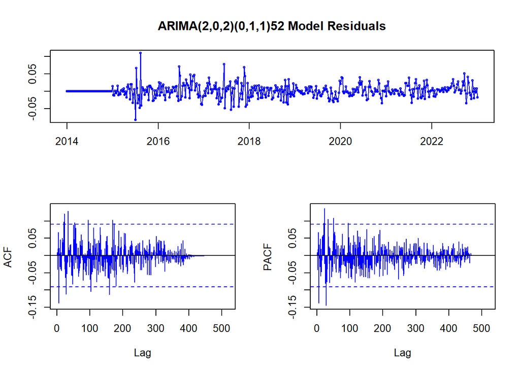

```r
tsdisplay(residuals(tmodel4.alt), lag.max=520,
          main='ARIMA(2,0,2)(0,1,1)52 Model Residuals', col="blue")
```

```
## [1] 85 79
```

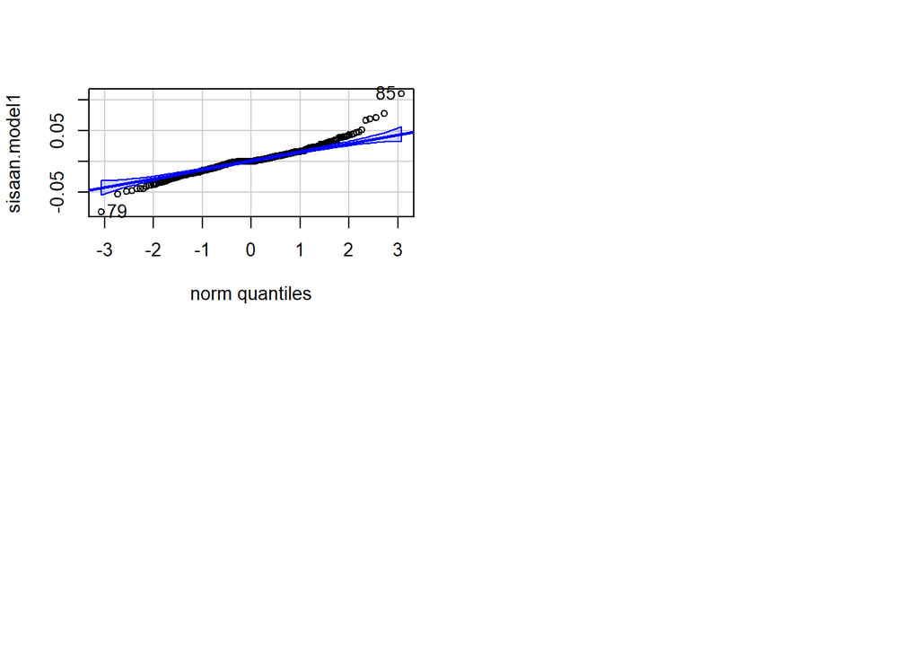

```r
#Eksplorasi
sisaan.model1 <- tmodel4.alt$residuals
par(mfrow=c(2,2))
car::qqPlot(sisaan.model1)
```

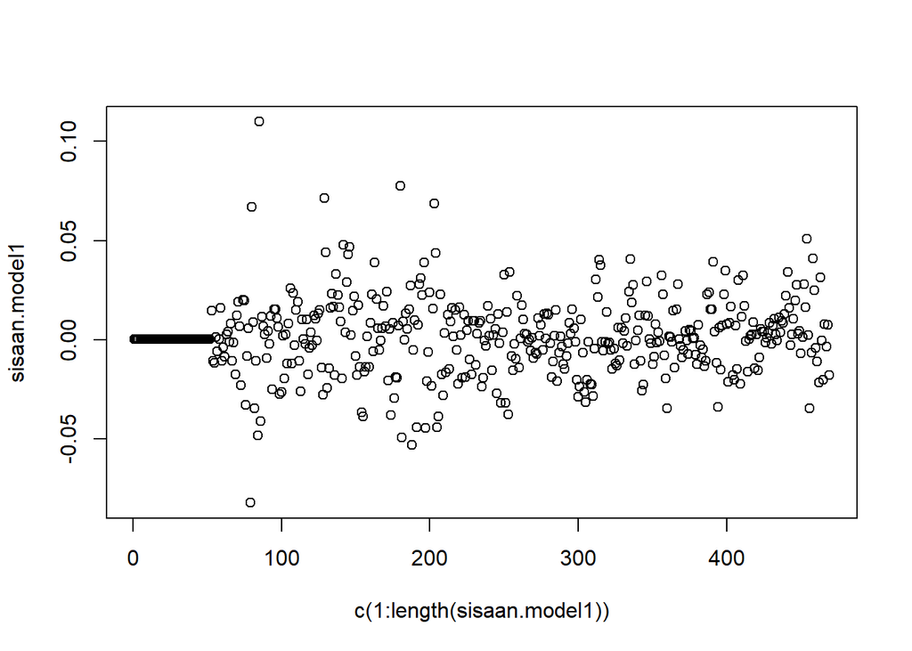

```r
plot(c(1:length(sisaan.model1)),sisaan.model1)
```

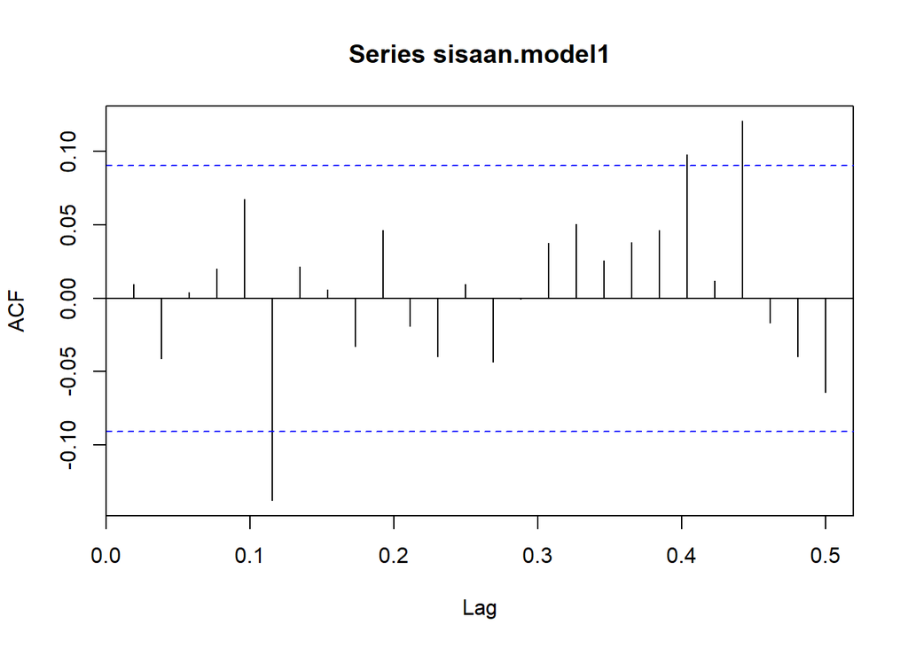

```r
acf(sisaan.model1)
```

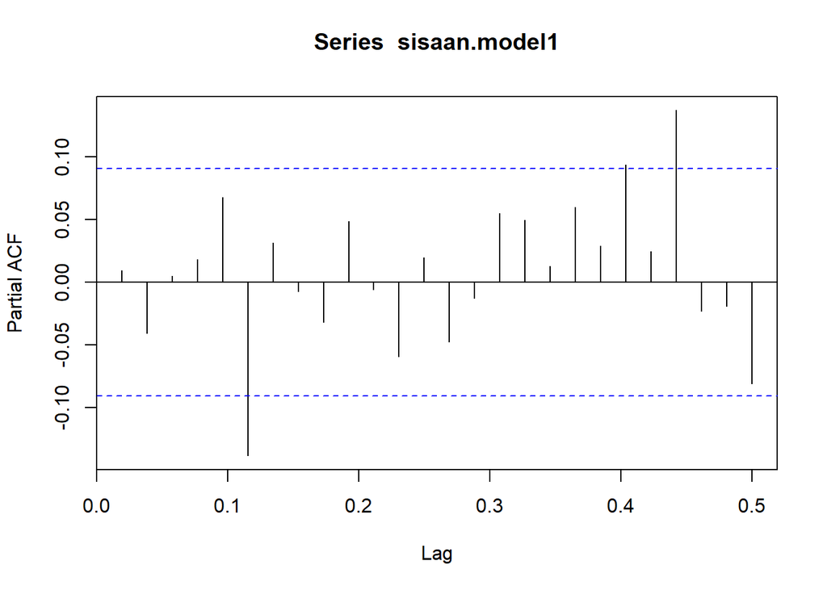

```r
pacf(sisaan.model1)
```

#### 5.4.2 Sisaan Menyebar Normal

```r
#1) Sisaan Menyebar Normal
ks.test(sisaan.model1,"pnorm")
```

```
##
##  Asymptotic one-sample Kolmogorov-Smirnov test
##
## data:  sisaan.model1
## D = 0.47669, p-value < 2.2e-16
## alternative hypothesis: two-sided
```

```r
shapiro.test(sisaan.model1)
```

```
##
##  Shapiro-Wilk normality test
##
## data:  sisaan.model1
## W = 0.9512, p-value = 2.532e-11
```

```r
nortest::ad.test(sisaan.model1)
```

```
##
##  Anderson-Darling normality test
##
## data:  sisaan.model1
## A = 5.714, p-value = 4.33e-14
```

residual tidak normal.

#### 5.4.2 Sisaan Saling Bebas

```r
#2) Sisaan saling bebas/tidak ada autokorelasi
Box.test(sisaan.model1, type = "Ljung")
```

```
##
##  Box-Ljung test
##
## data:  sisaan.model1
## X-squared = 0.042268, df = 1, p-value = 0.8371
```

tidak ada autokorelasi yang signifikan pada residual.

#### 5.4.3 Sisaan Homogen

```r
#3) Sisaan homogen
Box.test((sisaan.model1)^2, type = "Ljung")
```

```
##
##  Box-Ljung test
##
## data:  (sisaan.model1)^2
## X-squared = 42.57, df = 1, p-value = 6.819e-11
```

sisaan tidak homogen

#### 5.4.4 Nilai tengah sisaan = 0

```r
#4) Nilai tengah sisaan sama dengan nol
t.test(sisaan.model1, mu = 0, conf.level = 0.95)
```

```
##
##  One Sample t-test
##
## data:  sisaan.model1
## t = 1.5983, df = 468, p-value = 0.1107
## alternative hypothesis: true mean is not equal to 0
## 95 percent confidence interval:
##  -0.0003243749  0.0031514499
## sample estimates:
##   mean of x
## 0.001413537
```

nilai tengah sisaan sama dengan nol

#### 5.4.5 Hasil Uji

```r
hasil_uji <- data.frame(
  "Aspek yang diuji" = c("Normalitas residual", "Autokorelasi residual",
                         "Heteroskedastisitas", "Rata-rata residual"),
  "Hasil" = c("❌ Tidak normal", "✅ Tidak ada", "❌ Ada", "✅ 0"),
  "Makna" = c("Bentuk distribusi residual tidak normal",
              "Residual acak, white noise",
              "Varians residual tidak konstan",
              "Model tidak bias (mean zero)")
)

kable(hasil_uji, align = c("l", "c", "l"))
```

| Aspek.yang.diuji | Hasil | Makna |
| --- | --- | --- |
| Normalitas residual | ❌ Tidak normal | Bentuk distribusi residual tidak normal |
| Autokorelasi residual | ✅ Tidak ada | Residual acak, white noise |
| Heteroskedastisitas | ❌ Ada | Varians residual tidak konstan |
| Rata-rata residual | ✅ 0 | Model tidak bias (mean zero) |

### 5.5 Peramalan

```r
ramalan_sarima = forecast::forecast(tmodel4.alt, 52)
ramalan_sarima
```

```
##          Point Forecast     Lo 80     Hi 80     Lo 95     Hi 95
## 2023.019      0.3796002 0.3519322 0.4072682 0.3372857 0.4219147
## 2023.038      0.3794059 0.3502448 0.4085670 0.3348078 0.4240040
## 2023.058      0.3752851 0.3438805 0.4066897 0.3272559 0.4233143
## 2023.077      0.3728167 0.3391476 0.4064858 0.3213243 0.4243092
## 2023.096      0.3690051 0.3333982 0.4046119 0.3145491 0.4234610
## 2023.115      0.3620131 0.3248795 0.3991467 0.3052222 0.4188041
## 2023.135      0.3631058 0.3248240 0.4013876 0.3045588 0.4216528
## 2023.154      0.3587402 0.3196194 0.3978611 0.2989101 0.4185704
## 2023.173      0.3628004 0.3230780 0.4025229 0.3020502 0.4235507
## 2023.192      0.3606588 0.3205107 0.4008070 0.2992575 0.4220602
## 2023.212      0.3602345 0.3197878 0.4006811 0.2983767 0.4220922
## 2023.231      0.3595910 0.3189366 0.4002454 0.2974155 0.4217665
## 2023.250      0.3633181 0.3225198 0.4041164 0.3009225 0.4257137
## 2023.269      0.3653184 0.3244208 0.4062160 0.3027710 0.4278658
## 2023.288      0.3659141 0.3249482 0.4068799 0.3032622 0.4285659
## 2023.308      0.3572398 0.3162271 0.3982525 0.2945163 0.4199634
## 2023.327      0.3619002 0.3208553 0.4029450 0.2991275 0.4246728
## 2023.346      0.3607290 0.3196622 0.4017958 0.2979228 0.4235353
## 2023.365      0.3538104 0.3127285 0.3948922 0.2909811 0.4166396
## 2023.385      0.3455354 0.3044433 0.3866274 0.2826905 0.4083803
## 2023.404      0.3408476 0.2997485 0.3819466 0.2779920 0.4037032
## 2023.423      0.3349018 0.2937980 0.3760057 0.2720389 0.3977647
## 2023.442      0.3251228 0.2840157 0.3662299 0.2622549 0.3879907
## 2023.462      0.3039977 0.2628884 0.3451070 0.2411264 0.3668690
## 2023.481      0.3077000 0.2665891 0.3488108 0.2448264 0.3705735
## 2023.500      0.2961376 0.2550257 0.3372495 0.2332624 0.3590128
## 2023.519      0.2799175 0.2388049 0.3210300 0.2170413 0.3427937
## 2023.538      0.2636759 0.2225629 0.3047889 0.2007989 0.3265528
## 2023.558      0.2644976 0.2233843 0.3056109 0.2016202 0.3273750
## 2023.577      0.2510498 0.2099363 0.2921633 0.1881721 0.3139275
## 2023.596      0.2462562 0.2051426 0.2873698 0.1833783 0.3091340
## 2023.615      0.2377688 0.1966552 0.2788825 0.1748909 0.3006467
## 2023.635      0.2408012 0.1996875 0.2819148 0.1779233 0.3036790
## 2023.654      0.2317587 0.1906452 0.2728722 0.1688810 0.2946364
## 2023.673      0.2216721 0.1805588 0.2627854 0.1587947 0.2845495
## 2023.692      0.2177508 0.1766378 0.2588639 0.1548739 0.2806278
## 2023.712      0.2188040 0.1776915 0.2599166 0.1559278 0.2816803
## 2023.731      0.2306246 0.1895127 0.2717365 0.1677493 0.2934998
## 2023.750      0.2460198 0.2049089 0.2871307 0.1831461 0.3088936
## 2023.769      0.2389949 0.1978854 0.2801044 0.1761233 0.3018664
## 2023.788      0.2431424 0.2020349 0.2842498 0.1802739 0.3060108
## 2023.808      0.2539356 0.2128310 0.2950401 0.1910716 0.3167995
## 2023.827      0.2730991 0.2319987 0.3141995 0.2102414 0.3359567
## 2023.846      0.2996949 0.2586002 0.3407895 0.2368461 0.3625437
## 2023.865      0.3204363 0.2793496 0.3615230 0.2575996 0.3832730
## 2023.885      0.3137778 0.2727016 0.3548540 0.2509572 0.3765984
## 2023.904      0.3403441 0.2992814 0.3814067 0.2775441 0.4031440
## 2023.923      0.3574265 0.3163802 0.3984729 0.2946516 0.4202015
## 2023.942      0.3749755 0.3339472 0.4160039 0.3122281 0.4377230
## 2023.962      0.3824982 0.3414864 0.4235100 0.3197761 0.4452203
## 2023.981      0.3716027 0.3306012 0.4126041 0.3088964 0.4343089
## 2024.000      0.3869802 0.3460723 0.4278882 0.3244169 0.4495436
```

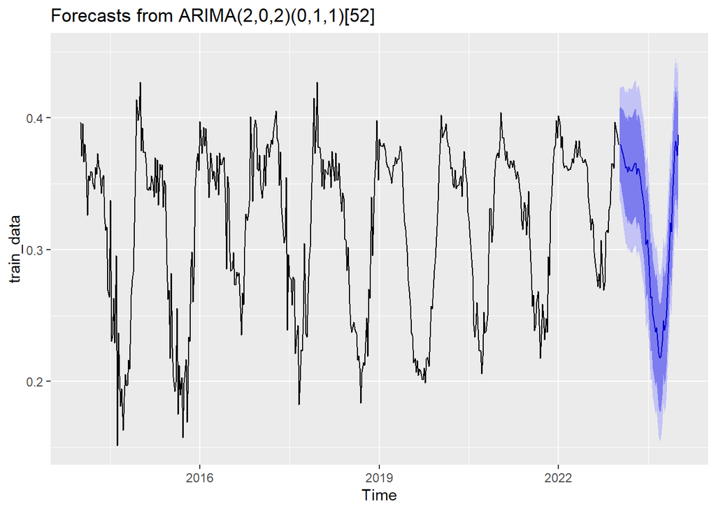

```r
autoplot(ramalan_sarima, col="blue")
```

```r
accuracy(ramalan_sarima,test_data)
```

```
##                       ME       RMSE        MAE       MPE     MAPE      MASE
## Training set 0.001413537 0.01918493 0.01327422 0.1644012 4.471595 0.4613226
## Test set     0.009418493 0.03494441 0.02652044 2.5847009 8.553895 0.9216722
##                     ACF1 Theil's U
## Training set 0.009463102        NA
## Test set     0.845280080  2.139851
```

## 6. TBATS

```r
fit_tbats <- tbats(data)
forecast(fit_tbats)
```

```
##          Point Forecast     Lo 80     Hi 80      Lo 95     Hi 95
## 2024.038      0.3650568 0.3393568 0.3907569 0.32575199 0.4043617
## 2024.058      0.3638358 0.3353737 0.3922978 0.32030683 0.4073647
## 2024.077      0.3616817 0.3307159 0.3926474 0.31432367 0.4090397
## 2024.096      0.3592445 0.3259746 0.3925145 0.30836252 0.4101265
## 2024.115      0.3570968 0.3216828 0.3925109 0.30293573 0.4112579
## 2024.135      0.3556797 0.3182536 0.3931057 0.29844149 0.4129178
## 2024.154      0.3552653 0.3159383 0.3945923 0.29511985 0.4154108
## 2024.173      0.3559399 0.3148064 0.3970733 0.29303170 0.4188481
## 2024.192      0.3576073 0.3147486 0.4004660 0.29206059 0.4231540
## 2024.212      0.3600131 0.3154994 0.4045268 0.29193527 0.4280910
## 2024.231      0.3627845 0.3166770 0.4088920 0.29226912 0.4332999
## 2024.250      0.3654811 0.3178336 0.4131287 0.29261047 0.4383518
## 2024.269      0.3676503 0.3185105 0.4167901 0.29249750 0.4428031
## 2024.288      0.3688794 0.3182907 0.4194682 0.29151058 0.4462483
## 2024.308      0.3688401 0.3168421 0.4208381 0.28931607 0.4483641
## 2024.327      0.3673186 0.3139489 0.4206884 0.28569661 0.4489407
## 2024.346      0.3642305 0.3095247 0.4189363 0.28056524 0.4478958
## 2024.365      0.3596180 0.3036109 0.4156250 0.27396262 0.4452733
## 2024.385      0.3536324 0.2963582 0.4109065 0.26603911 0.4412256
## 2024.404      0.3465052 0.2879974 0.4050130 0.25702524 0.4359852
## 2024.423      0.3385123 0.2788035 0.3982211 0.24719555 0.4298290
## 2024.442      0.3299368 0.2690585 0.3908150 0.23683146 0.4230420
## 2024.462      0.3210368 0.2590190 0.3830546 0.22618879 0.4158848
## 2024.481      0.3120223 0.2488929 0.3751517 0.21547425 0.4085704
## 2024.500      0.3030437 0.2388280 0.3672593 0.20483432 0.4012530
## 2024.519      0.2941936 0.2289142 0.3594729 0.19435743 0.3940297
## 2024.538      0.2855216 0.2191981 0.3518451 0.18408855 0.3869546
## 2024.558      0.2770581 0.2097069 0.3444092 0.17405339 0.3800627
## 2024.577      0.2688431 0.2004780 0.3372081 0.16428779 0.3733983
## 2024.596      0.2609554 0.1915879 0.3303229 0.15486701 0.3670438
## 2024.615      0.2535365 0.1831761 0.3238968 0.14592964 0.3611433
## 2024.635      0.2468035 0.1754589 0.3181481 0.13769137 0.3559157
## 2024.654      0.2410503 0.1687296 0.3133710 0.13044535 0.3516552
## 2024.673      0.2366322 0.1633440 0.3099205 0.12454752 0.3487169
## 2024.692      0.2339378 0.1596915 0.3081841 0.12038783 0.3474878
## 2024.712      0.2333486 0.1581551 0.3085422 0.11834997 0.3483473
## 2024.731      0.2351927 0.1590643 0.3113211 0.11876438 0.3516211
## 2024.750      0.2396969 0.1626477 0.3167461 0.12186026 0.3575335
## 2024.769      0.2469446 0.1689900 0.3248993 0.12772327 0.3661660
```

[output cut: 50 more lines]

```
## 2025.750      0.2400965 0.1255622 0.3546309 0.06493137 0.4152617
## 2025.769      0.2473046 0.1321604 0.3624489 0.07120674 0.4234025
## 2025.788      0.2571700 0.1414230 0.3729169 0.08015027 0.4341897
## 2025.808      0.2694137 0.1530717 0.3857557 0.09148399 0.4473434
## 2025.827      0.2835741 0.1666449 0.4005032 0.10474637 0.4624017
## 2025.846      0.2990315 0.1815228 0.4165401 0.11931747 0.4787455
## 2025.865      0.3150523 0.1969711 0.4331335 0.13446268 0.4956419
## 2025.885      0.3308468 0.2121991 0.4494945 0.14939086 0.5123028
## 2025.904      0.3456358 0.2264266 0.4648450 0.16332100 0.5279505
## 2025.923      0.3587181 0.2389511 0.4784852 0.17555029 0.5418860
## 2025.942      0.3695330 0.2492108 0.4898553 0.18551605 0.5535500
## 2025.962      0.3777084 0.2568324 0.4985843 0.19284460 0.5625721
## 2025.981      0.3830910 0.2616621 0.5045199 0.19738158 0.5688005
## 2026.000      0.3857549 0.2637733 0.5077366 0.19920010 0.5723098
## 2026.019      0.3859862 0.2634517 0.5085208 0.19858586 0.5733866
```

```r
n <- length(data)

fit_tbats <- tbats(train_data)
pred_tbats <- forecast(fit_tbats, h = 52)

accuracy(pred_tbats, test_data)  # cek MAPE, RMSE, dsb
```

```
##                        ME       RMSE        MAE        MPE     MAPE      MASE
## Training set  0.001252613 0.02033152 0.01500978 -0.1491591 5.130191 0.5216391
## Test set     -0.009700214 0.03387390 0.02549292 -3.5081103 8.435723 0.8859624
##                     ACF1 Theil's U
## Training set -0.03788813        NA
## Test set      0.87154089  2.234714
```